# SI model of a vaccine trial

2021-02-12

We are modeling a closed population SI model meant to simulate a vaccine trial. We are not modeling infections from I to S but rather only infections from the outside population, with infection rate based on the population prevalence `prev` (of viremic individuals), the exposure rate (serodiscordant sexual contacts per time) `c`, and the transmission rate (per contact) `p`. The per contact effect of vaccination is `epsilon`, and at this iteration of the model `epsilon` is not time-varying (the per contact vaccine effect does not decay over time).

p = transmission rate (per contact)  
c = exposure rate (serodiscordant sexual contacts per time)  
prev = prevalence (this should probably be prevalence of viremic individuals)  
lambda = p * c * prev  
epsilon = per contact vaccine efficacy; vaccine-induced reduction in the risk of HIV infection from a single exposure

## Model setup

Basic functions:

`dS/dt = -lambda*S`  
`dI/dt = lambda*S`

Sp = susceptible placebo  
Ip = infected placebo  
Sv = susceptible vaccinated  
Iv = infected vaccinated

Svh = susceptible vaccinated high exposure  
SvL = susceptible vaccinated low exposure  
Ivh = infected vaccinated high exposure  
Ivl = infected vaccinated low exposure

```r
p <- 0.01   #transmission rate (per contact)
c <- 0.25   #contact rate (contacts per time)
prev <- 0.20
lambda <- p*c*prev
epsilon <- 0.50 #per act vaccine efficacy
risk <- 3.0 #risk multiplier
```

```r
si_ode <- function(times, init, param){
  with(as.list(c(init, param)), {

    # Flows
    # the number of people moving from S to I at each time step
    SIp.flow <- lambda*Sp
    SIv.flow <- lambda*epsilon*Sv
    SIvh.flow <- risk*lambda*(1-epsilon)*Svh
    SIvl.flow <- lambda*(1-epsilon)*Svl

    # ODEs
    #placebo; homogeneous risk
    dSp <- -SIp.flow
    dIp <- SIp.flow  #lambda*Sp

    # vaccine; homogeneous risk
    dSv <- -SIv.flow
    dIv <- SIv.flow  #lambda*epsilon*Sv

    # vaccine; heterogeneous risk
    dSvh <- -SIvh.flow
    dIvh <- SIvh.flow  #risk*lambda*(1-epsilon)*Svh
    dSvl <- -SIvl.flow
    dIvl <- SIvl.flow  #lambda*(1-epsilon)*Svl

    #Output
    list(c(dSp,dIp,
           dSv,dIv,
           dSvh,dIvh,
           dSvl,dIvl,
           SIp.flow,SIv.flow,SIvh.flow,SIvl.flow))
  })
}
```

```r
param <- param.dcm(lambda = lambda, epsilon = epsilon, risk = risk)
init <- init.dcm(Sp = 5000, Ip = 1,
                 Sv = 5000, Iv = 1,
                 Svh = 2500, Ivh = 1,
                 Svl = 2500, Ivl = 1,
                 SIp.flow = 0, SIv.flow = 0, SIvh.flow = 0, SIvl.flow = 0)

control <- control.dcm(nsteps = 365*3, new.mod = si_ode)

mod <- dcm(param, init, control)
mod
```

```
## EpiModel Simulation
## =======================
## Model class: dcm
##
## Simulation Summary
## -----------------------
## No. runs: 1
## No. time steps: 1095
##
## Model Parameters
## -----------------------
## lambda = 5e-04
## epsilon = 0.5
## risk = 3
##
## Model Output
## -----------------------
## Variables: Sp Ip Sv Iv Svh Ivh Svl Ivl SIp.flow SIv.flow
## SIvh.flow SIvl.flow
```

```r
df <- as.data.frame(mod)
head(df, 25)
```

```
##    time       Sp        Ip       Sv        Iv      Svh       Ivh      Svl
## 1     1 5000.000  1.000000 5000.000  1.000000 2500.000  1.000000 2500.000
## 2     2 4997.501  3.499375 4998.750  2.249844 2498.126  2.874297 2499.375
## 3     3 4995.002  5.997501 4997.501  3.499375 2496.253  4.747189 2498.750
## 4     4 4992.506  8.494378 4996.251  4.748594 2494.381  6.618677 2498.126
## 5     5 4990.010 10.990007 4995.002  5.997501 2492.511  8.488761 2497.501
## 6     6 4987.516 13.484388 4993.754  7.246095 2490.643 10.357444 2496.877
## 7     7 4985.022 15.977522 4992.506  8.494378 2488.775 12.224725 2496.253
## 8     8 4982.531 18.469411 4991.258  9.742348 2486.909 14.090607 2495.629
## 9     9 4980.040 20.960053 4990.010 10.990007 2485.045 15.955090 2495.005
## 10   10 4977.551 23.449451 4988.763 12.237353 2483.182 17.818175 2494.381
## 11   11 4975.062 25.937604 4987.516 13.484388 2481.320 19.679863 2493.758
## 12   12 4972.575 28.424513 4986.269 14.731111 2479.460 21.540155 2493.134
## 13   13 4970.090 30.910180 4985.022 15.977522 2477.601 23.399053 2492.511
## 14   14 4967.605 33.394603 4983.776 17.223622 2475.743 25.256557 2491.888
```

[output cut: 37 more lines]

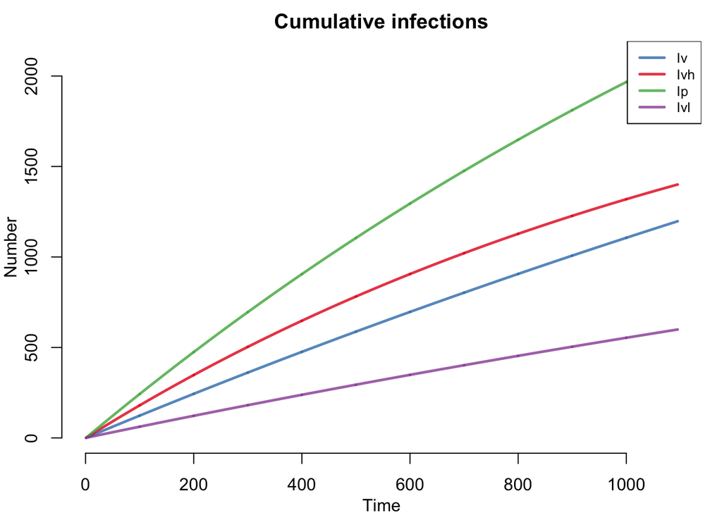

```r
par(mar = c(3,3,2,1), mgp = c(2,1,0))
plot(mod, y = c("Iv", "Ivh", "Ip", "Ivl"),
     alpha = 0.8,
     main = "Cumulative infections",
     legend = "full")
```

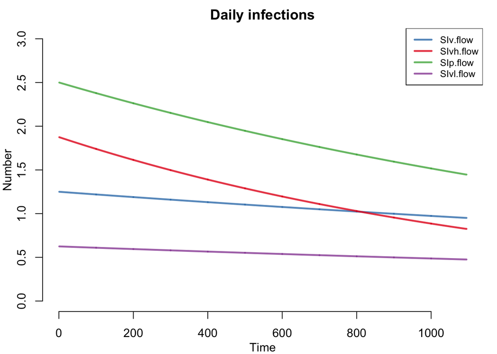

```r
plot(mod, y = c("SIv.flow", "SIvh.flow", "SIp.flow", "SIvl.flow"),
     alpha = 0.8,
     main = "Daily infections",
     legend = "full")
```